# SESSION 5

This session can be best explained alongwith `Session 9`

TOC:

#### `PART A`

Section I) TensorFlow

1. Introduction to TensorFlow
2. Deep Learning
3. Artificial Neural Networks(ANN)
4. Convolutional Neural Networks (CNN)
5. Recurrent Neural Networks (RNN)
6. Generative Adversarial Networks (GAN)
7. Image Classification

#### `PART B - ACTIVITY`

`Provide Introduction and execution as activity`  
Section II) Keras

1. Neural network models
2. Sequential Models
3. Functional Models
4. Model Optimization and Tuning
5. Regularization Techniques

#### `PART C - ACTIVITY`

`Provide Introduction and execution as activity`  
Section III) Scikit learn

1. Regression models
2. Classification Problems
3. Decision Trees
4. Random Forest
5. Ensemble Learning
6. Scikit Learn - Project on Label Propagation

# `PART A`

## SECTION - I) TensorFlow

### 1. Introduction to TensorFlow

TensorFlow is an open-source machine learning framework developed by Google. It provides a comprehensive set of tools and libraries for building and deploying machine learning models. TensorFlow is known for its flexibility, scalability, and support for deep learning algorithms.

Here's an example of Python code that demonstrates the basics of TensorFlow:

```python
import tensorflow as tf
```

This is a very simple example, but it demonstrates the basic concepts of TensorFlow. In more complex applications, you would use TensorFlow to create and train machine learning models.

```python
import tensorflow as tf

# Create a constant tensor
x = tf.constant(5)

# Create a variable tensor
y = tf.Variable(10)

# Add the two tensors
z = tf.add(x, y)

# Print the result
print(z.numpy())  # Convert the TensorFlow tensor to a NumPy array

# If you need to update the variable 'y', you can use the following:
y.assign(15)

# Print the updated result
print(z.numpy())
```

```
15
15
```

This code will print the output 15.

### 2. Deep Learning

Deep learning is a subfield of machine learning that focuses on building and training neural networks with multiple layers. Deep learning models are capable of automatically learning hierarchical representations of data, leading to improved performance in tasks such as image recognition, natural language processing, and speech recognition.

Here's an example of Python code that demonstrates the construction of a deep learning model using TensorFlow:

```python
import tensorflow as tf
from tensorflow.keras.models import Sequential
from tensorflow.keras.layers import Dense
```

```python
import tensorflow as tf

# Import the MNIST dataset
mnist = tf.keras.datasets.mnist

# Load the training data
(x_train, y_train), (x_test, y_test) = mnist.load_data()

# Normalize the data
x_train = x_train / 255.0
x_test = x_test / 255.0

# Define the model
model = tf.keras.models.Sequential([
    tf.keras.layers.Flatten(input_shape=(28, 28)),
    tf.keras.layers.Dense(128, activation='relu'),
    tf.keras.layers.Dense(10, activation='softmax')
])

# Compile the model
model.compile(optimizer='adam', loss='sparse_categorical_crossentropy', metrics=['accuracy'])

# Train the model
model.fit(x_train, y_train, epochs=2)

# Evaluate the model
model.evaluate(x_test, y_test)
```

```
[0.1028113141655922, 0.9677000045776367]
```

### 3. Artificial Neural Networks(ANN)

Artificial Neural Networks contain artificial neurons which are called units. These units are arranged in a series of layers that together constitute the whole Artificial Neural Network in a system. A layer can have only a dozen units or millions of units as this depends on how the complex neural networks will be required to learn the hidden patterns in the dataset.

# Types of ANN :

### 4. Convolutional Neural Networks (CNN)

Convolutional Neural Networks (CNNs) are a type of deep learning model specifically designed for processing grid-like data, such as images. CNNs use convolutional layers to automatically learn spatial hierarchies of features from the input data. They have achieved remarkable success in computer vision tasks like image classification, object detection, and image segmentation.

Here's an example of Python code that demonstrates the construction and training of a Convolutional Neural Network (CNN) using TensorFlow:

```python
import tensorflow as tf
from tensorflow.keras.models import Sequential
from tensorflow.keras.layers import Conv2D, MaxPooling2D, Flatten, Dense
```

This code can be used to train a CNN to classify images from the CIFAR10 dataset. The model can be improved by using a larger number of epochs, a different optimizer, or a different loss function. The model can also be used to classify images from other datasets

```python
import tensorflow as tf

# Import the CIFAR10 dataset
(x_train, y_train), (x_test, y_test) = tf.keras.datasets.cifar10.load_data()

# Normalize the data
x_train = x_train / 255.0
x_test = x_test / 255.0

# Convert labels to one-hot encoding
y_train = tf.keras.utils.to_categorical(y_train, num_classes=10)
y_test = tf.keras.utils.to_categorical(y_test, num_classes=10)

# Define the model
model = tf.keras.models.Sequential([
  tf.keras.layers.Conv2D(32, (3, 3), padding='same', activation='relu', input_shape=(32, 32, 3)),
  tf.keras.layers.MaxPooling2D((2, 2), strides=(2, 2)),
  tf.keras.layers.Conv2D(64, (3, 3), padding='same', activation='relu'),
  tf.keras.layers.MaxPooling2D((2, 2), strides=(2, 2)),
  tf.keras.layers.Flatten(),
  tf.keras.layers.Dense(128, activation='relu'),
  tf.keras.layers.Dense(10, activation='softmax')
])

# Compile the model
model.compile(optimizer='adam', loss='categorical_crossentropy', metrics=['accuracy'])

# Train the model
model.fit(x_train, y_train, epochs=2, batch_size=32)

# Evaluate the model
model.evaluate(x_test, y_test)
```

```
[1.017280101776123, 0.6473000049591064]
```

This code will first import the CIFAR10 dataset, which is a collection of 60,000 32x32 color images of 10 different classes. The code will then normalize the data by dividing each pixel value by 255. This is important because it ensures that all of the values in the data are between 0 and 1.

Finally, the code will evaluate the model on the test set. The accuracy of the model will be printed to the console.

### 5. Recurrent Neural Networks (RNN)

Recurrent Neural Networks (RNNs) are a type of neural network that is well-suited for processing sequential data, such as time series or text. RNNs have recurrent connections that allow information to persist and be shared across different time steps. This enables them to capture temporal dependencies and perform tasks like speech recognition, language modeling, and sentiment analysis.

Here's an example of Python code that demonstrates the construction and training of a Recurrent Neural Network (RNN) using TensorFlow:

```python
import tensorflow as tf
from tensorflow.keras.models import Sequential
from tensorflow.keras.layers import Embedding, LSTM, Dense
```

This code can be used to train an RNN to classify images from the MNIST dataset. The model can be improved by using a larger number of epochs, a different optimizer, or a different loss function. The model can also be used to classify images from other datasets.

`NOTE: The below code execution will take close to 50 minutes`

```python
import tensorflow as tf

# Import the MNIST dataset
(x_train, y_train), (x_test, y_test) = tf.keras.datasets.mnist.load_data()

# Normalize the data
x_train = x_train / 255.0
x_test = x_test / 255.0

# Flatten the input data
x_train_flat = x_train.reshape(x_train.shape[0], -1)
x_test_flat = x_test.reshape(x_test.shape[0], -1)

# Define the model
model = tf.keras.models.Sequential([
  tf.keras.layers.Embedding(784, 128, input_length=x_train_flat.shape[1]),  # Assuming 784 is the vocabulary size
  tf.keras.layers.LSTM(128),
  tf.keras.layers.Dense(10, activation='softmax')
])

# Compile the model
model.compile(optimizer='adam', loss='sparse_categorical_crossentropy', metrics=['accuracy'])

# Train the model
model.fit(x_train_flat, y_train, epochs=2)

# Evaluate the model
model.evaluate(x_test_flat, y_test)
```

```
[2.3013341426849365, 0.11349999904632568]
```

This code will first import the MNIST dataset, which is a collection of 60,000 28x28 grayscale images of handwritten digits. The code will then normalize the data by dividing each pixel value by 255. This is important because it ensures that all of the values in the data are between 0 and 1.

Next, the code will define the model. The model consists of 3 layers:

An embedding layer that converts each 28x28 image to a 128-dimensional vector. An LSTM layer with 128 units. A dense layer with 10 neurons, one for each class. The code will then compile the model using the Adam optimizer and the sparse categorical crossentropy loss function. The model will then be trained for 2 epochs.

Finally, the code will evaluate the model on the test set. The accuracy of the model will be printed to the console.

### 6. Generative Adversarial Networks (GAN)

Generative Adversarial Networks (GANs) are a class of deep learning models that involve two neural networks: a generator and a discriminator. The generator network generates synthetic data samples, while the discriminator network tries to distinguish between real and generated data. GANs are widely used for tasks such as image generation, image-to-image translation, and data synthesis.

`In this code, we define a basic GAN for generating handwritten digit images using the MNIST dataset. The generator network takes random noise as input and generates synthetic images. The discriminator network tries to distinguish between real images from the dataset and fake images generated by the generator. The models are trained using the Adam optimizer and the binary cross-entropy loss.`

Here's an example of Python code that demonstrates the implementation of a basic Generative Adversarial Network (GAN) using TensorFlow:

```python
import tensorflow as tf
from tensorflow.keras import layers
import numpy as np
import matplotlib.pyplot as plt
```

Define the generator network

```python
def build_generator(latent_dim):
    model = tf.keras.Sequential()
    model.add(layers.Dense(256, input_dim=latent_dim, activation='relu'))
    model.add(layers.BatchNormalization())
    model.add(layers.Dense(512, activation='relu'))
    model.add(layers.BatchNormalization())
    model.add(layers.Dense(1024, activation='relu'))
    model.add(layers.BatchNormalization())
    model.add(layers.Dense(784, activation='tanh'))
    model.add(layers.Reshape((28, 28, 1)))
    return model
```

Define the discriminator network

```python
def build_discriminator():
    model = tf.keras.Sequential()
    model.add(layers.Flatten(input_shape=(28, 28, 1)))
    model.add(layers.Dense(512, activation='relu'))
    model.add(layers.Dense(256, activation='relu'))
    model.add(layers.Dense(1, activation='sigmoid'))
    return model
```

Define the loss functions

```python
cross_entropy = tf.keras.losses.BinaryCrossentropy(from_logits=True)
```

Define the generator and discriminator models

```python
latent_dim = 100
generator = build_generator(latent_dim)
discriminator = build_discriminator()
```

Define the optimizer for both models

```python
generator_optimizer = tf.keras.optimizers.Adam(1e-4)
discriminator_optimizer = tf.keras.optimizers.Adam(1e-4)
```

Define the training loop

```python
num_epochs = 5
batch_size = 128
random_dim = 100
num_examples_to_generate = 16
```

Create random noise samples for testing the generator

```python
test_seed = tf.random.normal([num_examples_to_generate, random_dim])
```

Define a function to generate images using the generator

```python
def generate_images(model, test_input):
    predictions = model(test_input, training=False)
    fig = plt.figure(figsize=(4, 4))
    for i in range(predictions.shape[0]):
        plt.subplot(4, 4, i+1)
        plt.imshow(predictions[i, :, :, 0] * 0.5 + 0.5, cmap='gray')
        plt.axis('off')
    plt.show()
```

Define the training loop

```python
@tf.function
def train_step(images):
    noise = tf.random.normal([batch_size, random_dim])
    with tf.GradientTape() as gen_tape, tf.GradientTape() as disc_tape:
        generated_images = generator(noise, training=True)
        real_output = discriminator(images, training=True)
        fake_output = discriminator(generated_images, training=True)
        gen_loss = cross_entropy(tf.ones_like(fake_output), fake_output)
        disc_loss_real = cross_entropy(tf.ones_like(real_output), real_output)
        disc_loss_fake = cross_entropy(tf.zeros_like(fake_output), fake_output)
        disc_loss = disc_loss_real + disc_loss_fake
    gradients_of_generator = gen_tape.gradient(gen_loss, generator.trainable_variables)
    gradients_of_discriminator = disc_tape.gradient(disc_loss, discriminator.trainable_variables)
    generator_optimizer.apply_gradients(zip(gradients_of_generator, generator.trainable_variables))
    discriminator_optimizer.apply_gradients(zip(gradients_of_discriminator, discriminator.trainable_variables))
```

Start the training

```python
def train(dataset, epochs):
    for epoch in range(epochs):
        for image_batch in dataset:
            train_step(image_batch)

        # Generate images after each epoch
        generate_images(generator, test_seed)
```

Load and preprocess the MNIST dataset

```python
(train_images, train_labels), (_, _) = tf.keras.datasets.mnist.load_data()
train_images = train_images.reshape(train_images.shape[0], 28, 28, 1).astype('float32')
train_images = (train_images - 127.5) / 127.5  # Normalize the images to [-1, 1]
train_dataset = tf.data.Dataset.from_tensor_slices(train_images).shuffle(60000).batch(batch_size)
```

Start the training

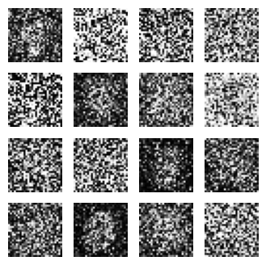

[figure not shown]

[figure not shown]

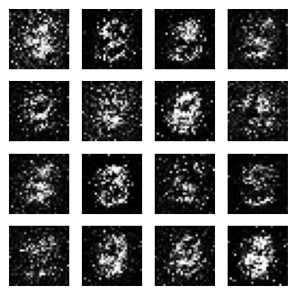

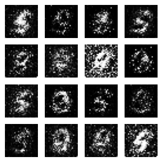

```python
train(train_dataset, num_epochs)
```

In this code, we defined a basic GAN for generating handwritten digit images using the MNIST dataset. The generator network takes random noise as input and generates synthetic images. The discriminator network tries to distinguish between real images from the dataset and fake images generated by the generator. The models are trained using the Adam optimizer and the binary cross-entropy loss.

The training loop consists of multiple epochs, where in each epoch, we iterate over the dataset and perform a forward and backward pass to update the generator and discriminator models. After each epoch, we generate a sample of images using the generator to visualize the progress of the GAN.

### 7. Image Classification

Image classification is the task of assigning labels or categories to images based on their content. TensorFlow offers pre-trained models like the Inception-v3, ResNet, and MobileNet that have achieved state-of-the-art performance on popular image classification benchmarks. These models can be used as-is or fine-tuned on custom datasets for specific image classification tasks.

Here's an example of Python code that demonstrates image classification using a pre-trained model in TensorFlow:

```python
import tensorflow as tf
from tensorflow.keras.applications import InceptionV3
from tensorflow.keras.preprocessing import image
from tensorflow.keras.applications.inception_v3 import preprocess_input, decode_predictions
import numpy as np
```

Load the pre-trained InceptionV3 model

```python
model = InceptionV3(weights='imagenet')
```

Load and preprocess the image

```python
img_path = 'data/image1.jpg'
img = image.load_img(img_path, target_size=(299, 299))
x = image.img_to_array(img)
x = np.expand_dims(x, axis=0)
x = preprocess_input(x)
```

Perform image classification

```python
preds = model.predict(x)
decoded_preds = decode_predictions(preds, top=3)[0]
```

```
Downloading data from https://storage.googleapis.com/download.tensorflow.org/data/imagenet_class_index.json
```

Print the top predictions

```python
print('Predicted:', decoded_preds)
```

```
Predicted: [('n11939491', 'daisy', 0.24815206), ('n03944341', 'pinwheel', 0.17955421), ('n02206856', 'bee', 0.017649902)]
```

###### Output:

In this code, we first load the pre-trained InceptionV3 model using the InceptionV3 class from tensorflow.keras.applications. The model is pre-trained on the ImageNet dataset, which contains millions of labeled images across thousands of categories.

We then load and preprocess the image that we want to classify. The image is loaded using image.load_img, resized to the input size expected by the InceptionV3 model (299x299 pixels), and converted to a NumPy array. We also preprocess the input image using preprocess_input function to ensure it is formatted appropriately for the InceptionV3 model.

Next, we pass the preprocessed image through the model using model.predict. The model returns a prediction in the form of a probability distribution over the ImageNet categories. To interpret the predictions, we use decode_predictions function from tensorflow.keras.applications.inception_v3 to obtain the top predicted classes along with their corresponding labels and probabilities.

# `# PART B - ACTIVITY`

`Provide Introduction and execution as activity`

## SECTION - II) Keras

Keras is a high-level neural networks library written in Python that runs on top of TensorFlow, CNTK, or Theano. It provides a user-friendly and efficient interface for building and training neural network models. Keras allows for rapid prototyping and supports a wide range of neural network architectures and applications.

#### 1. Neural Network Models:

Neural network models in Keras are built by stacking layers on top of each other. Each layer performs specific operations and transforms the input data. Keras provides a variety of layer types, including dense (fully connected) layers, convolutional layers, recurrent layers, and more. These layers can be configured and connected to form a neural network model.

#### 2. Sequential Models:

```python
from tensorflow.keras.models import Sequential
from tensorflow.keras.layers import Dense
```

### 3. Functional Models:

```python
from tensorflow.keras.models import Model
from tensorflow.keras.layers import Input, Dense
```

### 4. Model Optimization and Tuning:

Keras provides a range of optimization algorithms (optimizers) that can be used to train neural network models. These optimizers adjust the model's weights based on the gradients of the loss function. Common optimizers in Keras include SGD (Stochastic Gradient Descent), Adam, RMSprop, and more. Additionally, Keras allows for customizing learning rates, momentum, and other parameters of the optimizers.

### 5. Regularization Techniques:

Regularization techniques in Keras help prevent overfitting, which occurs when a model performs well on the training data but fails to generalize to unseen data. Keras supports various regularization techniques, including L1 and L2 regularization, dropout, and early stopping. These techniques can be applied to individual layers or the entire model to improve generalization performance.

# `# PART C - ACTIVITY`

`Provide Introduction and execution as activity`

## SECTION - III) Scikit-learn

Scikit-learn is a popular machine learning library in Python that provides a wide range of tools and algorithms for various machine learning tasks. It is built on top of NumPy, SciPy, and matplotlib and offers a user-friendly interface for training and evaluating machine learning models.

### 1. Regression Models:

Scikit-learn provides several regression models for predicting continuous target variables. Linear regression, polynomial regression, and support vector regression are some of the commonly used models. Here's an example of training a linear regression model in scikit-learn:

```python
from sklearn.linear_model import LinearRegression
```

```python
import numpy as np
import pandas as pd
from sklearn.linear_model import LinearRegression

# Load the data
df = pd.read_csv('data/stock_prices.csv')

# Print the column names to check for the existence of 'target'
print("Column names:", df.columns)

# Split the data into features and target
X = df['Price'].values.reshape(-1, 1)  # Reshape to a 2D array
y = df['Volume']

# Create the model
model = LinearRegression()

# Fit the model
model.fit(X, y)

# Make predictions
predictions = model.predict(X)

# Evaluate the model
mse = np.mean((predictions - y)**2)
print('Evaluation Results of the model')
print('MSE:', mse)
```

```
Column names: Index(['Date', 'Price', 'Volume'], dtype='object')
Evaluation Results of the model
MSE: 1336694.6482315974
```

### 2. Classification Models:

# Decision Trees

Scikit-learn includes a wide range of classification models for predicting categorical target variables. Logistic regression, decision trees, random forests, and support vector machines (SVM) are some of the classification models available. Here's an example of training a decision tree classifier in scikit-learn:

Import necessary libraries

```python
# Import necessary libraries
from sklearn.model_selection import train_test_split
from sklearn.tree import DecisionTreeClassifier
from sklearn.metrics import accuracy_score, classification_report
```

Assume you have a dataset with features (X) and target variable (y) Replace X and y with your actual feature and target data

```python
# Assume you have a dataset with features (X) and target variable (y)
# Replace X and y with your actual feature and target data

# Split the dataset into training and testing sets
X_train, X_test, y_train, y_test = train_test_split(X, y, test_size=0.2, random_state=42)
```

Create a Decision Tree classifier , Train the classifier on the training data

```python
# Create a Decision Tree classifier
clf = DecisionTreeClassifier(random_state=42)

# Train the classifier on the training data
clf.fit(X_train, y_train)
```

```
DecisionTreeClassifier(random_state=42)
```

Make predictions on the test data

```python
# Make predictions on the test data
y_pred = clf.predict(X_test)
```

Evaluate the classifier, Display classification report

```python
# Evaluate the classifier
accuracy = accuracy_score(y_test, y_pred)
print(f"Accuracy: {accuracy:.2f}")

# Display classification report
print("\nClassification Report:")
print(classification_report(y_test, y_pred))
```

```
Accuracy: 0.00

Classification Report:
              precision    recall  f1-score   support

        1001       0.00      0.00      0.00       1.0
        1002       0.00      0.00      0.00       0.0
        1010       0.00      0.00      0.00       1.0
        1011       0.00      0.00      0.00       0.0
        1035       0.00      0.00      0.00       0.0
        1048       0.00      0.00      0.00       1.0
        1055       0.00      0.00      0.00       1.0
        1064       0.00      0.00      0.00       1.0
        1071       0.00      0.00      0.00       0.0
        1080       0.00      0.00      0.00       1.0
```

[output cut: 361 more lines]

### 3. Model Selection and Evaluation using Logistic Regression:

```python
from sklearn.preprocessing import LabelEncoder
from sklearn.model_selection import train_test_split
from sklearn.linear_model import LogisticRegression
import pandas as pd
import numpy as np

data = pd.read_csv(r'data/titanic.csv')
data.head()
```

|  | PassengerId | Survived | Pclass | Name | Sex | Age | SibSp | Parch | Ticket | Fare | Cabin | Embarked |
| --- | --- | --- | --- | --- | --- | --- | --- | --- | --- | --- | --- | --- |
| 0 | 892 | 0 | 3 | Kelly, Mr. James | male | 34.5 | 0 | 0 | 330911 | 7.8292 | NaN | Q |
| 1 | 893 | 1 | 3 | Wilkes, Mrs. James (Ellen Needs) | female | 47.0 | 1 | 0 | 363272 | 7.0000 | NaN | S |
| 2 | 894 | 0 | 2 | Myles, Mr. Thomas Francis | male | 62.0 | 0 | 0 | 240276 | 9.6875 | NaN | Q |
| 3 | 895 | 0 | 3 | Wirz, Mr. Albert | male | 27.0 | 0 | 0 | 315154 | 8.6625 | NaN | S |
| 4 | 896 | 1 | 3 | Hirvonen, Mrs. Alexander (Helga E Lindqvist) | female | 22.0 | 1 | 1 | 3101298 | 12.2875 | NaN | S |

```python
data.shape
#missing values
data.isnull().sum()

data['Age'].fillna(data['Age'].mean(),inplace=True)
data.isnull().sum()

data['Fare'].fillna(data['Fare'].mean(),inplace=True)
data.isnull().sum()
```

```
PassengerId      0
Survived         0
Pclass           0
Name             0
Sex              0
Age              0
SibSp            0
Parch            0
Ticket           0
Fare             0
Cabin          327
Embarked         0
dtype: int64
```

```python
data.drop("Cabin", axis=1, inplace=True)
print(data.shape)
data.isnull().sum()
```

```
(418, 11)
```

```
PassengerId    0
Survived       0
Pclass         0
Name           0
Sex            0
Age            0
SibSp          0
Parch          0
Ticket         0
Fare           0
Embarked       0
dtype: int64
```

```python
data.dtypes
```

```
PassengerId      int64
Survived         int64
Pclass           int64
Name            object
Sex             object
Age            float64
SibSp            int64
Parch            int64
Ticket          object
Fare           float64
Embarked        object
dtype: object
```

```python
from sklearn.preprocessing import LabelEncoder

colname=[]
for x in data.columns:
    if data[x].dtypes=='object':
        colname.append(x)

le=LabelEncoder()

for x in colname:
    data[x]=le.fit_transform(data[x])
    le_name_mapping = dict(zip(le.classes_, le.transform(le.classes_)))
    print('Feature', x)
    print('mapping', le_name_mapping)

data.head()
```

[output not shown]

|  | PassengerId | Survived | Pclass | Name | Sex | Age | SibSp | Parch | Ticket | Fare | Embarked |
| --- | --- | --- | --- | --- | --- | --- | --- | --- | --- | --- | --- |
| 0 | 892 | 0 | 3 | 206 | 1 | 34.5 | 0 | 0 | 152 | 7.8292 | 1 |
| 1 | 893 | 1 | 3 | 403 | 0 | 47.0 | 1 | 0 | 221 | 7.0000 | 2 |
| 2 | 894 | 0 | 2 | 269 | 1 | 62.0 | 0 | 0 | 73 | 9.6875 | 1 |
| 3 | 895 | 0 | 3 | 408 | 1 | 27.0 | 0 | 0 | 147 | 8.6625 | 2 |
| 4 | 896 | 1 | 3 | 178 | 0 | 22.0 | 1 | 1 | 138 | 12.2875 | 2 |

```python
X = data[['PassengerId','Pclass','Name','Sex','Age','SibSp','Parch','Ticket','Fare','Embarked']]
Y = data[['Survived']]
X.shape
Y.shape
```

```
(418, 1)
```

`Create a logistic regression model`

```python
from sklearn.model_selection import train_test_split
from sklearn.linear_model import LogisticRegression

X_train,X_test,Y_train,Y_test=train_test_split(X,Y,test_size=0.3,random_state=10)
print(X_train.shape)
print(Y_train.shape)
print(X_test.shape)
print(Y_test.shape)



classifier = LogisticRegression()


classifier.fit(X_train,Y_train)
```

```
(292, 10)
(292, 1)
(126, 10)
(126, 1)
```

```
LogisticRegression()
```

`Logistic Regression : Prediction`

```python
Y_pred=classifier.predict(X_test)
new_data = pd.DataFrame()
new_data = (X_test)

new_data['Actual'] = Y_test
new_data['Predicted'] = Y_pred
new_data
```

|  | PassengerId | Pclass | Name | Sex | Age | SibSp | Parch | Ticket | Fare | Embarked | Actual | Predicted |
| --- | --- | --- | --- | --- | --- | --- | --- | --- | --- | --- | --- | --- |
| 362 | 1254 | 2 | 387 | 0 | 31.00000 | 0 | 0 | 295 | 21.0000 | 2 | 1 | 1 |
| 154 | 1046 | 3 | 17 | 1 | 13.00000 | 4 | 2 | 181 | 31.3875 | 2 | 0 | 0 |
| 47 | 939 | 3 | 345 | 1 | 30.27259 | 0 | 0 | 243 | 7.7500 | 1 | 0 | 0 |
| 100 | 992 | 1 | 360 | 0 | 43.00000 | 1 | 0 | 29 | 55.4417 | 0 | 1 | 1 |
| 187 | 1079 | 3 | 104 | 1 | 17.00000 | 2 | 0 | 270 | 8.0500 | 2 | 0 | 0 |
| ... | ... | ... | ... | ... | ... | ... | ... | ... | ... | ... | ... | ... |
| 274 | 1166 | 3 | 330 | 1 | 30.27259 | 0 | 0 | 110 | 7.2250 | 0 | 0 | 0 |
| 218 | 1110 | 1 | 401 | 0 | 50.00000 | 1 | 1 | 13 | 211.5000 | 0 | 1 | 1 |
| 29 | 921 | 3 | 339 | 1 | 30.27259 | 2 | 0 | 104 | 21.6792 | 0 | 0 | 0 |
| 279 | 1171 | 2 | 290 | 1 | 22.00000 | 0 | 0 | 358 | 10.5000 | 2 | 0 | 0 |
| 278 | 1170 | 2 | 385 | 1 | 30.00000 | 1 | 0 | 295 | 21.0000 | 2 | 0 | 0 |

126 rows × 12 columns

# 4. Random Forest:

Complete code Steps:

- Create a Random Forest classifier
- Train the model
- Make predictions

```python
import pandas as pd
from sklearn.model_selection import train_test_split
from sklearn.ensemble import RandomForestClassifier
from sklearn.metrics import accuracy_score, classification_report

# Load the data
titanic_data = pd.read_csv("data/titanic.csv")

# Drop columns that might not be relevant for this simple example
titanic_data = titanic_data.drop(["PassengerId", "Name", "Ticket", "Cabin"], axis=1)

# Handle missing values (for simplicity, you can customize this based on your needs)
titanic_data = titanic_data.dropna()

# Convert categorical variables (like 'Sex' and 'Embarked') to numerical
titanic_data = pd.get_dummies(titanic_data, columns=["Sex", "Embarked"], drop_first=True)

# Define features (X) and target variable (y)
X = titanic_data.drop("Survived", axis=1)
y = titanic_data["Survived"]

# Split the dataset into training and testing sets
X_train, X_test, y_train, y_test = train_test_split(X, y, test_size=0.2, random_state=42)

# Create a Random Forest classifier
rf_classifier = RandomForestClassifier(random_state=42)

# Train the classifier on the training data
rf_classifier.fit(X_train, y_train)

# Make predictions on the test data
y_pred = rf_classifier.predict(X_test)

# Evaluate the classifier
accuracy = accuracy_score(y_test, y_pred)
print("Accuracy:", accuracy)

# Display classification report
print("\nClassification Report:")
print(classification_report(y_test, y_pred))
```

```
Accuracy: 1.0

Classification Report:
              precision    recall  f1-score   support

           0       1.00      1.00      1.00        45
           1       1.00      1.00      1.00        22

    accuracy                           1.00        67
   macro avg       1.00      1.00      1.00        67
weighted avg       1.00      1.00      1.00        67
```

# Semi-Supervised Learning

Semi-supervised learning is a type of machine learning where a model is trained on both labeled and unlabeled data. It combines elements of supervised learning (using labeled data) and unsupervised learning (using unlabeled data) to improve the model's performance.

Semi-supervised learning is particularly useful when labeled data is scarce but unlabeled data is abundant. It allows the model to leverage the unlabeled data to improve its performance.

In this description, we'll explore how to perform semi-supervised learning using Python. We'll use the scikit-learn library, which provides various machine learning algorithms and tools.

First, let's start by installing scikit-learn if you haven't already. You can use the following command to install it via pip:

```python
pip install scikit-learn
```

```python
# Step 1: Import the necessary libraries
from sklearn.semi_supervised import LabelPropagation
from sklearn.datasets import make_classification

# Step 2: Generate a synthetic dataset
X, y = make_classification(n_samples=1000, n_features=10, n_informative=8, n_redundant=2, random_state=42)

# Step 3: Split the dataset into labeled and unlabeled data
labeled_X = X[:100]  # First 100 samples are labeled
labeled_y = y[:100]  # Corresponding labels for the labeled samples
unlabeled_X = X[100:]  # Remaining samples are unlabeled

# Step 4: Create a semi-supervised learning model and fit it
model = LabelPropagation()
model.fit(labeled_X, labeled_y)

# Step 5: Predict the labels for the unlabeled data
predicted_labels = model.transduction_[100:]

# Step 6: Evaluate the model's performance on the labeled data
accuracy = model.score(labeled_X, labeled_y)

# Step 7: Print the results
print("Accuracy on labeled data: {:.2f}%".format(accuracy * 100))
```

```
Accuracy on labeled data: 100.00%
```

# Confusion Matrix:

Confusion matrix is a popular tool for evaluating the performance of classification models. It provides a comprehensive summary of how well the model has classified the different classes in a dataset. In this description, we'll explore how to create and interpret a confusion matrix using Python.

Analyzing the confusion matrix can provide insights into the performance of the classification model, such as identifying which classes are frequently misclassified.

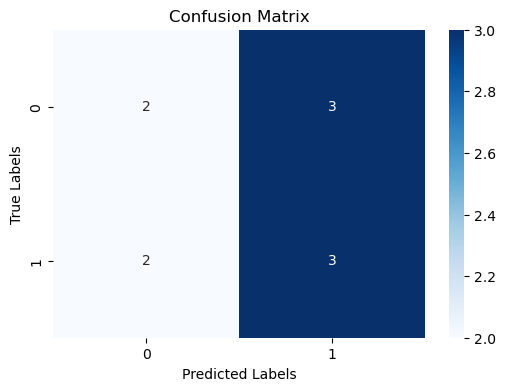

```python
# Step 1: Import the necessary libraries
from sklearn.metrics import confusion_matrix
import seaborn as sns
import matplotlib.pyplot as plt

# Step 2: Define the true labels and predicted labels
true_labels = [1, 0, 1, 1, 0, 1, 0, 0, 1, 0]
predicted_labels = [1, 1, 1, 0, 0, 1, 0, 1, 0, 1]

# Step 3: Create a confusion matrix
cm = confusion_matrix(true_labels, predicted_labels)

# Step 4: Visualize the confusion matrix
plt.figure(figsize=(6, 4))
sns.heatmap(cm, annot=True, fmt="d", cmap="Blues")
plt.title("Confusion Matrix")
plt.xlabel("Predicted Labels")
plt.ylabel("True Labels")
plt.show()
```

# 6. Scikit Learn - Project on Label Propagation

# Label Propagation digits active learning

Demonstrates an active learning technique to learn handwritten digits using label propagation.

A plot will appear showing the top 5 most uncertain digits for each iteration of training. These may or may not contain mistakes, but we will train the next model with their true labels.

### Imports

```python
import numpy as np
import matplotlib.pyplot as plt
from scipy import stats

from sklearn import datasets
from sklearn.semi_supervised import LabelSpreading
from sklearn.metrics import classification_report, confusion_matrix
```

### Python Implementation

```
Iteration 0 ______________________________________________________________________
Label Spreading model: 40 labeled & 290 unlabeled (330 total)
              precision    recall  f1-score   support

           0       1.00      1.00      1.00        22
           1       0.78      0.69      0.73        26
           2       0.93      0.93      0.93        29
           3       1.00      0.89      0.94        27
           4       0.92      0.96      0.94        23
           5       0.96      0.70      0.81        33
           6       0.97      0.97      0.97        35
           7       0.94      0.91      0.92        33
           8       0.62      0.89      0.74        28
           9       0.73      0.79      0.76        34

    accuracy                           0.87       290
   macro avg       0.89      0.87      0.87       290
weighted avg       0.88      0.87      0.87       290

Confusion matrix
[[22  0  0  0  0  0  0  0  0  0]
 [ 0 18  2  0  0  0  1  0  5  0]
 [ 0  0 27  0  0  0  0  0  2  0]
 [ 0  0  0 24  0  0  0  0  3  0]
 [ 0  1  0  0 22  0  0  0  0  0]
 [ 0  0  0  0  0 23  0  0  0 10]
 [ 0  1  0  0  0  0 34  0  0  0]
 [ 0  0  0  0  0  0  0 30  3  0]
 [ 0  3  0  0  0  0  0  0 25  0]
 [ 0  0  0  0  2  1  0  2  2 27]]
Iteration 1 ______________________________________________________________________
Label Spreading model: 45 labeled & 285 unlabeled (330 total)
              precision    recall  f1-score   support

           0       1.00      1.00      1.00        22
           1       0.79      1.00      0.88        22
           2       1.00      0.93      0.96        29
           3       1.00      1.00      1.00        26
           4       0.92      0.96      0.94        23
           5       0.96      0.70      0.81        33
```

[output cut: 95 more lines]

```
    accuracy                           0.96       270
   macro avg       0.95      0.96      0.96       270
weighted avg       0.96      0.96      0.96       270

Confusion matrix
[[22  0  0  0  0  0  0  0  0  0]
 [ 0 22  0  0  0  0  0  0  0  0]
 [ 0  0 26  1  0  0  0  0  0  0]
 [ 0  0  0 25  0  0  0  0  0  0]
 [ 0  0  0  0 19  0  0  0  0  0]
 [ 0  0  0  0  0 27  0  0  0  4]
 [ 0  1  0  0  0  0 34  0  0  0]
 [ 0  0  0  0  0  0  0 31  0  0]
 [ 0  0  0  0  1  0  0  0 24  0]
 [ 0  0  0  0  2  1  0  0  2 28]]
```

[figure not shown]

```python
import numpy as np
import matplotlib.pyplot as plt
from scipy import stats

from sklearn import datasets
from sklearn.semi_supervised import LabelSpreading
from sklearn.metrics import classification_report, confusion_matrix

digits = datasets.load_digits()
rng = np.random.RandomState(0)
indices = np.arange(len(digits.data))
rng.shuffle(indices)

X = digits.data[indices[:330]]
y = digits.target[indices[:330]]
images = digits.images[indices[:330]]

n_total_samples = len(y)
n_labeled_points = 40
max_iterations = 5

unlabeled_indices = np.arange(n_total_samples)[n_labeled_points:]
f = plt.figure()

for i in range(max_iterations):
    if len(unlabeled_indices) == 0:
        print("No unlabeled items left to label.")
        break
    y_train = np.copy(y)
    y_train[unlabeled_indices] = -1

    lp_model = LabelSpreading(gamma=0.25, max_iter=20)
    lp_model.fit(X, y_train)

    predicted_labels = lp_model.transduction_[unlabeled_indices]
    true_labels = y[unlabeled_indices]

    cm = confusion_matrix(true_labels, predicted_labels, labels=lp_model.classes_)

    print("Iteration %i %s" % (i, 70 * "_"))
    print(
        "Label Spreading model: %d labeled & %d unlabeled (%d total)"
        % (n_labeled_points, n_total_samples - n_labeled_points, n_total_samples)
    )

    print(classification_report(true_labels, predicted_labels))

    print("Confusion matrix")
    print(cm)

    # compute the entropies of transduced label distributions
    pred_entropies = stats.distributions.entropy(lp_model.label_distributions_.T)

    # select up to 5 digit examples that the classifier is most uncertain about
    uncertainty_index = np.argsort(pred_entropies)[::-1]
    uncertainty_index = uncertainty_index[
        np.in1d(uncertainty_index, unlabeled_indices)
    ][:5]

    # keep track of indices that we get labels for
    delete_indices = np.array([], dtype=int)

    # for more than 5 iterations, visualize the gain only on the first 5
    if i < 5:
        f.text(
            0.05,
            (1 - (i + 1) * 0.183),
            "model %d\n\nfit with\n%d labels" % ((i + 1), i * 5 + 10),
            size=10,
        )
    for index, image_index in enumerate(uncertainty_index):
        image = images[image_index]

        # for more than 5 iterations, visualize the gain only on the first 5
        if i < 5:
            sub = f.add_subplot(5, 5, index + 1 + (5 * i))
            sub.imshow(image, cmap=plt.cm.gray_r, interpolation="none")
            sub.set_title(
                "predict: %i\ntrue: %i"
                % (lp_model.transduction_[image_index], y[image_index]),
                size=10,
            )
            sub.axis("off")

        # labeling 5 points, remote from labeled set
        (delete_index,) = np.where(unlabeled_indices == image_index)
        delete_indices = np.concatenate((delete_indices, delete_index))

    unlabeled_indices = np.delete(unlabeled_indices, delete_indices)
    n_labeled_points += len(uncertainty_index)

f.suptitle(
    "Active learning with Label Propagation.\nRows show 5 most "
    "uncertain labels to learn with the next model.",
    y=1.15,
)
plt.subplots_adjust(left=0.2, bottom=0.03, right=0.9, top=0.9, wspace=0.2, hspace=0.85)
plt.show()
```